# Resource Quality Experiment Analysis

```r
mgrowthmod_contrasts <- emmeans(mgrowthmod, specs = pairwise ~ Diet + Infection | Clone, type = "response")
mgrowthmod_contrasts
```

```
## $emmeans
## Clone = Mid37:
##  Diet Infection  emmean   SE    df lower.CL upper.CL
##  S    Uninfected   40.5 3.52  3.35    29.97     51.1
##  SM   Uninfected   32.5 3.62  3.73    22.21     42.9
##  M    Uninfected   28.4 3.62  3.73    18.08     38.7
##  M+   Uninfected   27.2 3.52  3.35    16.60     37.7
##  S    Exposed      33.3 6.07 25.43    20.77     45.7
##  SM   Exposed      30.5 4.32  7.42    20.39     40.6
##  M    Exposed      20.7 4.06  5.88    10.74     30.7
##  M+   Exposed      20.9 3.62  3.73    10.57     31.2
##  S    Infected     33.1 3.87  4.89    23.08     43.1
##  SM   Infected     21.8 8.24 58.73     5.31     38.3
##  M    Infected   nonEst   NA    NA       NA       NA
##  M+   Infected   nonEst   NA    NA       NA       NA
##
## Clone = Standard:
##  Diet Infection  emmean   SE    df lower.CL upper.CL
##  S    Uninfected   38.6 3.73  4.21    28.46     48.8
##  SM   Uninfected   35.6 3.52  3.35    25.08     46.2
##  M    Uninfected   36.4 3.52  3.35    25.85     47.0
##  M+   Uninfected   32.0 3.62  3.73    21.69     42.4
##  S    Exposed    nonEst   NA    NA       NA       NA
##  SM   Exposed      35.8 3.87  4.89    25.76     45.8
##  M    Exposed      31.1 5.17 14.54    20.10     42.2
##  M+   Exposed      33.9 3.52  3.35    23.37     44.5
##  S    Infected     29.3 3.62  3.73    18.96     39.6
##  SM   Infected     27.4 8.24 58.73    10.88     43.9
##  M    Infected   nonEst   NA    NA       NA       NA
##  M+   Infected   nonEst   NA    NA       NA       NA
##
## Degrees-of-freedom method: kenward-roger
## Confidence level used: 0.95
##
## $contrasts
## Clone = Mid37:
##  contrast                        estimate   SE  df t.ratio p.value
##  S Uninfected - SM Uninfected       7.985 3.59 115   2.222  0.5372
##  S Uninfected - M Uninfected       12.117 3.59 115   3.372  0.0451
##  S Uninfected - (M+ Uninfected)    13.365 3.50 115   3.823  0.0111
```

[output cut: 120 more lines]

```
##  M Exposed - M Infected            nonEst   NA  NA      NA      NA
##  M Exposed - (M+ Infected)         nonEst   NA  NA      NA      NA
##  (M+ Exposed) - S Infected          4.642 3.59 115   1.292  0.9786
##  (M+ Exposed) - SM Infected         6.559 8.23 115   0.796  0.9997
##  (M+ Exposed) - M Infected         nonEst   NA  NA      NA      NA
##  (M+ Exposed) - (M+ Infected)      nonEst   NA  NA      NA      NA
##  S Infected - SM Infected           1.917 8.27 115   0.232  1.0000
##  S Infected - M Infected           nonEst   NA  NA      NA      NA
##  S Infected - (M+ Infected)        nonEst   NA  NA      NA      NA
##  SM Infected - M Infected          nonEst   NA  NA      NA      NA
##  SM Infected - (M+ Infected)       nonEst   NA  NA      NA      NA
##  M Infected - (M+ Infected)        nonEst   NA  NA      NA      NA
##
## Degrees-of-freedom method: kenward-roger
## P value adjustment: tukey method for comparing a family of 12 estimates
```

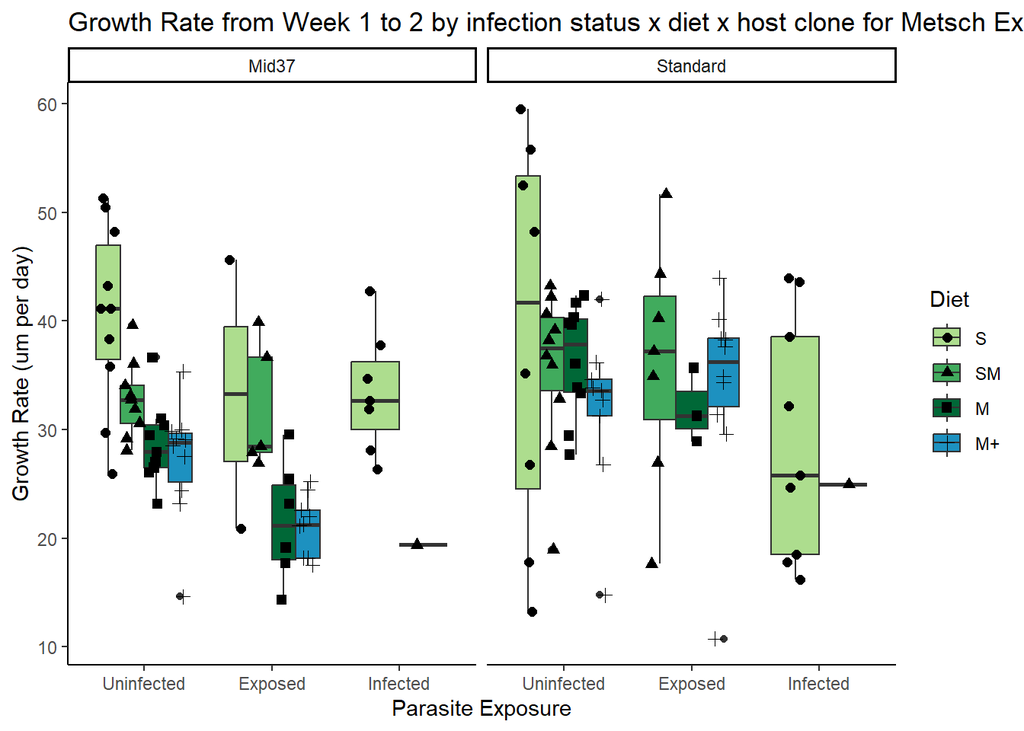

```r
m_growth <- ggplot(m_data_growth, aes(x = Infection, y = GrowthRate)) +
  geom_boxplot(aes(fill=Diet),position=position_dodge()) +
  geom_point(aes(shape=Diet), size=2, position=position_jitterdodge()) +
  facet_wrap(~Clone) +
  scale_x_discrete(limits = c("Uninfected", "Exposed", "Infected")) +
  scale_fill_discrete(limits = c("S", "SM", "M", "M+")) +
  scale_shape_discrete(limits = c("S", "SM", "M", "M+")) +
  scale_fill_manual(values = diet_colors) +
  ggtitle("Growth Rate from Week 1 to 2 by infection status x diet x host clone for Metsch Expt") +
  labs(x = "Parasite Exposure", y = "Growth Rate (um per day)") +
  theme_classic()
m_growth
```

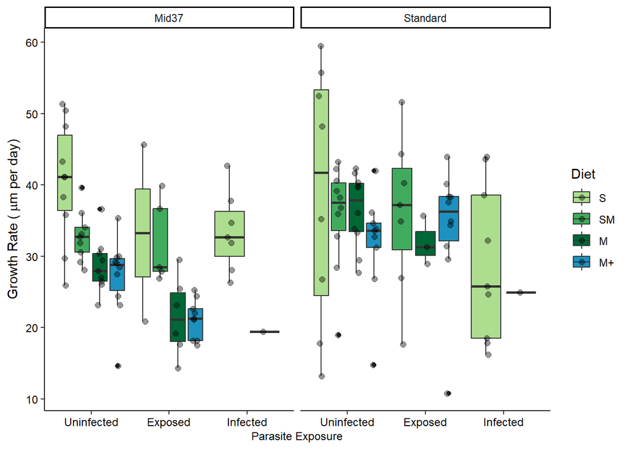

```r
# figure for presentation
m_growth2 <- ggplot(m_data_growth, aes(x = Infection, y = GrowthRate)) +
  geom_boxplot(aes(fill=Diet),position=position_dodge(width =0.9)) +
  geom_point(aes(color=Diet), size=2, position=position_jitterdodge(dodge.width=0.9, jitter.width = 0.2), alpha = 0.4) +
  facet_wrap(~Clone) +
  scale_x_discrete(limits = c("Uninfected", "Exposed", "Infected")) +
  scale_fill_discrete(limits = c("S", "SM", "M", "M+")) +
  scale_fill_manual(values = diet_colors) +
  scale_color_manual(values = c(rep("black", 4))) +
  #ggtitle("Growth Rate from Week 1 to 2 by infection status x diet x host clone for Metsch Expt") +
  labs(x = "Parasite Exposure", y = bquote("Growth Rate ("~ mu* "m per day)")) +
  theme_classic() +
  theme(axis.text = element_text(size=9, color = "black"), axis.title.y = element_text(size=11, color="black"),
        axis.title.x = element_text(size=9, color="black"))
m_growth2
```

```r
ggsave("figures/MetschGrowthRate_DietxClonexInfection.tiff", plot = m_growth2, dpi = 600, width = 6.5, height = 4, units = "in", compression="lzw")
```

There are significant differences for Diet, infection status, and host clone, but no sig interactions between any of those factors. As with the Pasteuria experiment, growth rate declined with poorer quality diets, Growth rate is lower in exposed or infected animals compared to uninfected animals, more so for the M and M+ treatments in Mid37s (less so for Standards).

## Bodysize over time for Pasteuria experiment

Need to do this still…

**Question 1:** Would these plots be useful or necessary compared to the growth rate ones from above?

**Question 2:** if yes, then what is the best way to show this data over time? I was thinking averaging by treatment for each week of the experiment with std error bars…

## Bodysize over time for Metsch experiment

Need to do this still…

## Survival analyses

### Pasteuria survival analyses

Need to remove some animals from data set? Which ones? Depending on whether we go with the Parasite treatment or the infection status (i.e. exposed vs infected vs uninfected) we may want to remove some categories where there are only one or two animals from the survival analysis.

Need to separate data based on host clone to make the plots easier to look at.

```r
p_data$Diet2 = recode_factor(p_data$Diet, 'SM' = "50:50 SM", .default = levels(p_data$Diet2))
p_data$Diet2 <- factor(p_data$Diet2, levels = c("S", "50:50 SM", "M", "M+"))

p_data$SurvObj <- with(p_data, Surv(lifespan.days, Status))


p_data_std <- p_data %>% filter(Clone == "Standard") %>% mutate(Treatment_Combo = paste(Diet, Infection, sep = "_"))
p_data_mid <- p_data %>% filter(Clone == "Mid37") %>% mutate(Treatment_Combo = paste(Diet, Infection, sep = "_"))
```

**Standard survival in the Pasteuria experiment**

Kaplan-Meier models estimate the survival probability and the long-rank test.

```r
p_data_std$SurvObj <- with(p_data_std, Surv(lifespan.days, Status))

# Kaplan-Meier estimator with "log-log" confidence interval
km.by.diet_parasite_std <- survfit(SurvObj ~ Diet + Parasites, data = p_data_std, conf.type = "log-log")
km.by.diet_parasite_std
```

```
## Call: survfit(formula = SurvObj ~ Diet + Parasites, data = p_data_std,
##     conf.type = "log-log")
##
##                                n events median 0.95LCL 0.95UCL
## Diet=S, Parasites=Uninfected  10      7   27.0      14      37
## Diet=S, Parasites=Pasteuria   10      5   37.0      14      NA
## Diet=SM, Parasites=Uninfected 10      5   29.0       6      NA
## Diet=SM, Parasites=Pasteuria  10      4     NA       7      NA
## Diet=M, Parasites=Uninfected  10      8   21.0       6      28
## Diet=M, Parasites=Pasteuria   11      9   17.0       9      22
## Diet=M+, Parasites=Uninfected 10      6   28.0      19      NA
## Diet=M+, Parasites=Pasteuria  10      8   18.5       9      29
```

```r
km.by.diet_infstatus_std <- survfit(SurvObj ~ Diet + Infection, data = p_data_std, conf.type = "log-log")
km.by.diet_infstatus_std
```

```
## Call: survfit(formula = SurvObj ~ Diet + Infection, data = p_data_std,
##     conf.type = "log-log")
##
##                                n events median 0.95LCL 0.95UCL
## Diet=S, Infection=Uninfected  10      7   27.0      14      37
## Diet=S, Infection=Exposed      9      5   30.5      14      NA
## Diet=S, Infection=Infected     1      0     NA      NA      NA
## Diet=SM, Infection=Uninfected 10      5   29.0       6      NA
## Diet=SM, Infection=Exposed    10      4     NA       7      NA
## Diet=M, Infection=Uninfected  10      8   21.0       6      28
## Diet=M, Infection=Exposed     11      9   17.0       9      22
## Diet=M+, Infection=Uninfected 10      6   28.0      19      NA
## Diet=M+, Infection=Exposed     9      7   18.0       9      NA
## Diet=M+, Infection=Infected    1      1   29.0      NA      NA
```

```r
km.by.diet_infstatus_std2 <- survfit(SurvObj ~ Diet2 + Infection, data = p_data_std, conf.type = "log-log")
km.by.diet_infstatus_std2
```

```
## Call: survfit(formula = SurvObj ~ Diet2 + Infection, data = p_data_std,
##     conf.type = "log-log")
##
##                                       n events median 0.95LCL 0.95UCL
## Diet2=S, Infection=Uninfected        10      7   27.0      14      37
## Diet2=S, Infection=Exposed            9      5   30.5      14      NA
## Diet2=S, Infection=Infected           1      0     NA      NA      NA
## Diet2=50:50 SM, Infection=Uninfected 10      5   29.0       6      NA
## Diet2=50:50 SM, Infection=Exposed    10      4     NA       7      NA
## Diet2=M, Infection=Uninfected        10      8   21.0       6      28
## Diet2=M, Infection=Exposed           11      9   17.0       9      22
## Diet2=M+, Infection=Uninfected       10      6   28.0      19      NA
## Diet2=M+, Infection=Exposed           9      7   18.0       9      NA
## Diet2=M+, Infection=Infected          1      1   29.0      NA      NA
```

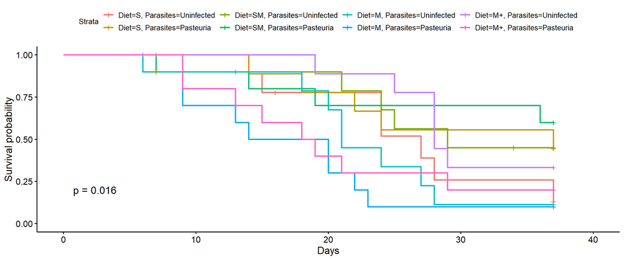

```r
ggsurvplot(km.by.diet_parasite_std, data = p_data_std, pval = TRUE, xlab = "Days")
```

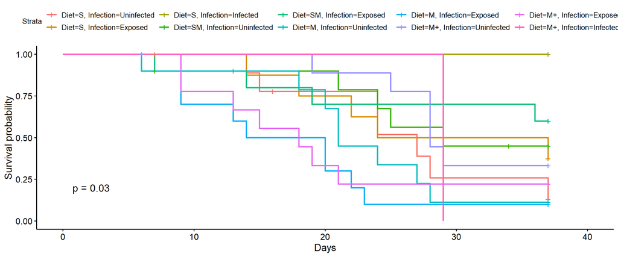

```r
ggsurvplot(km.by.diet_infstatus_std, data = p_data_std, pval = TRUE, xlab = "Days")
```

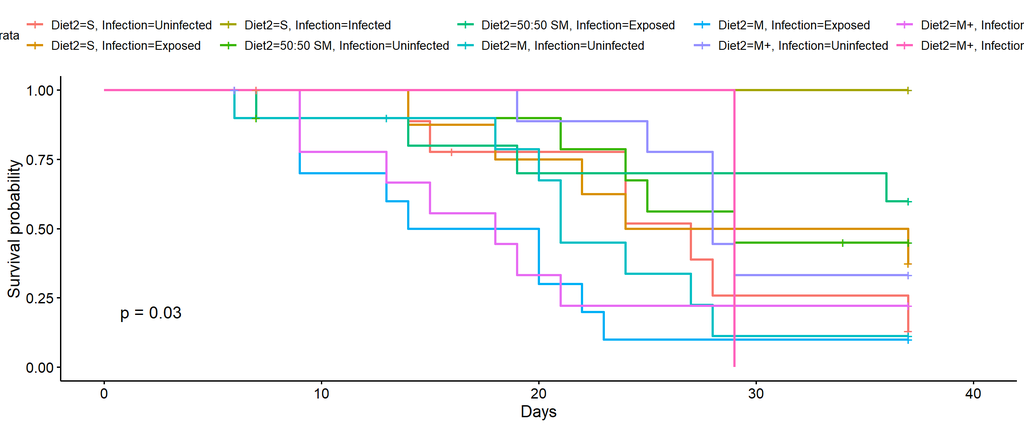

```r
ggsurvplot(km.by.diet_infstatus_std2, data = p_data_std, pval = TRUE, xlab = "Days")
```

```r
# Cox proportional hazards model
cox.diet_parasite_std <- coxph(SurvObj ~ Diet + Parasites, data = p_data_std)
cox.diet_parasite_std
```

```
## Call:
## coxph(formula = SurvObj ~ Diet + Parasites, data = p_data_std)
##
##                       coef exp(coef) se(coef)      z      p
## DietSM             -0.4880    0.6138   0.4418 -1.105 0.2693
## DietM               0.8439    2.3254   0.3847  2.194 0.0283
## DietM+              0.2051    1.2277   0.3976  0.516 0.6059
## ParasitesPasteuria  0.1808    1.1981   0.2833  0.638 0.5234
##
## Likelihood ratio test=10.96  on 4 df, p=0.02697
## n= 81, number of events= 52
```

```r
cox.diet_infstatus_std <- coxph(SurvObj ~ Diet + Infection, data = p_data_std)
summary(cox.diet_infstatus_std)
```

```
## Call:
## coxph(formula = SurvObj ~ Diet + Infection, data = p_data_std)
##
##   n= 81, number of events= 52
##
##                      coef exp(coef) se(coef)      z Pr(>|z|)
## DietSM            -0.5526    0.5754   0.4440 -1.245   0.2133
## DietM              0.7927    2.2093   0.3852  2.058   0.0396 *
## DietM+             0.2107    1.2345   0.3980  0.529   0.5966
## InfectionExposed   0.2438    1.2761   0.2871  0.849   0.3957
## InfectionInfected -0.7260    0.4839   1.0296 -0.705   0.4807
## ---
## Signif. codes:  0 '***' 0.001 '**' 0.01 '*' 0.05 '.' 0.1 ' ' 1
##
##                   exp(coef) exp(-coef) lower .95 upper .95
## DietSM               0.5754     1.7378   0.24101     1.374
## DietM                2.2093     0.4526   1.03848     4.700
## DietM+               1.2345     0.8100   0.56584     2.693
## InfectionExposed     1.2761     0.7836   0.72703     2.240
## InfectionInfected    0.4839     2.0667   0.06432     3.640
##
## Concordance= 0.649  (se = 0.042 )
## Likelihood ratio test= 12.15  on 5 df,   p=0.03
## Wald test            = 11.96  on 5 df,   p=0.04
## Score (logrank) test = 12.94  on 5 df,   p=0.02
```

```r
cox.diet_infstatus_std2 <- coxph(SurvObj ~ Diet2 + Infection, data = p_data_std)
summary(cox.diet_infstatus_std2)
```

```
## Call:
## coxph(formula = SurvObj ~ Diet2 + Infection, data = p_data_std)
##
##   n= 81, number of events= 52
##
##                      coef exp(coef) se(coef)      z Pr(>|z|)
## Diet250:50 SM     -0.5526    0.5754   0.4440 -1.245   0.2133
## Diet2M             0.7927    2.2093   0.3852  2.058   0.0396 *
## Diet2M+            0.2107    1.2345   0.3980  0.529   0.5966
## InfectionExposed   0.2438    1.2761   0.2871  0.849   0.3957
## InfectionInfected -0.7260    0.4839   1.0296 -0.705   0.4807
## ---
## Signif. codes:  0 '***' 0.001 '**' 0.01 '*' 0.05 '.' 0.1 ' ' 1
##
##                   exp(coef) exp(-coef) lower .95 upper .95
## Diet250:50 SM        0.5754     1.7378   0.24101     1.374
## Diet2M               2.2093     0.4526   1.03848     4.700
## Diet2M+              1.2345     0.8100   0.56584     2.693
## InfectionExposed     1.2761     0.7836   0.72703     2.240
## InfectionInfected    0.4839     2.0667   0.06432     3.640
##
## Concordance= 0.649  (se = 0.042 )
## Likelihood ratio test= 12.15  on 5 df,   p=0.03
## Wald test            = 11.96  on 5 df,   p=0.04
## Score (logrank) test = 12.94  on 5 df,   p=0.02
```

```r
cox.diet_infstatus_clone <- coxph(SurvObj ~ Diet2 + Infection + Clone, data = p_data)
summary(cox.diet_infstatus_clone)
```

```
## Call:
## coxph(formula = SurvObj ~ Diet2 + Infection + Clone, data = p_data)
##
##   n= 162, number of events= 94
##
##                      coef exp(coef) se(coef)      z Pr(>|z|)
## Diet250:50 SM     -0.8039    0.4476   0.3593 -2.237  0.02526 *
## Diet2M             0.8106    2.2492   0.2831  2.863  0.00419 **
## Diet2M+            0.4284    1.5348   0.2886  1.484  0.13772
## InfectionExposed   0.5515    1.7359   0.2183  2.526  0.01153 *
## InfectionInfected -0.4719    0.6238   0.4457 -1.059  0.28976
## CloneStandard      0.2423    1.2742   0.2132  1.137  0.25566
## ---
## Signif. codes:  0 '***' 0.001 '**' 0.01 '*' 0.05 '.' 0.1 ' ' 1
##
##                   exp(coef) exp(-coef) lower .95 upper .95
## Diet250:50 SM        0.4476     2.2343    0.2213    0.9051
## Diet2M               2.2492     0.4446    1.2914    3.9174
## Diet2M+              1.5348     0.6515    0.8717    2.7023
## InfectionExposed     1.7359     0.5761    1.1316    2.6627
## InfectionInfected    0.6238     1.6030    0.2604    1.4944
## CloneStandard        1.2742     0.7848    0.8391    1.9349
##
## Concordance= 0.695  (se = 0.028 )
## Likelihood ratio test= 40.55  on 6 df,   p=4e-07
## Wald test            = 35.79  on 6 df,   p=3e-06
## Score (logrank) test = 39.62  on 6 df,   p=5e-07
```

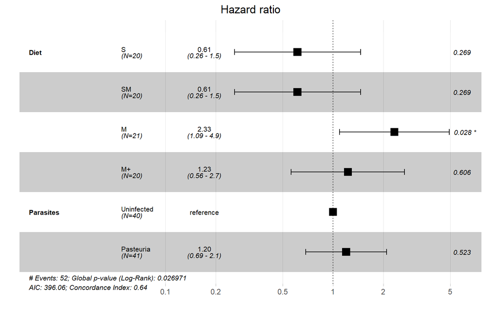

```r
# forest plot
ggforest(cox.diet_parasite_std, data = p_data_std)
```

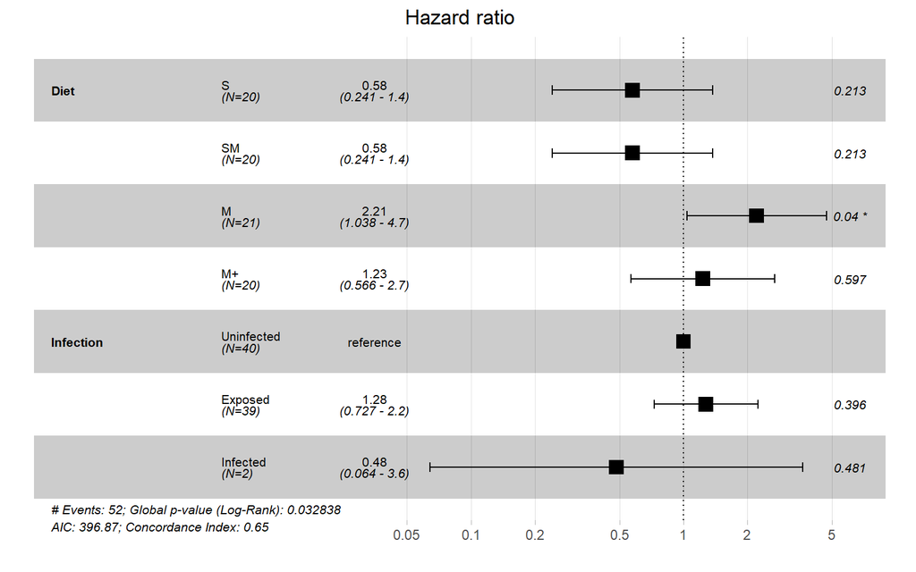

```r
ggforest(cox.diet_infstatus_std, data = p_data_std)
```

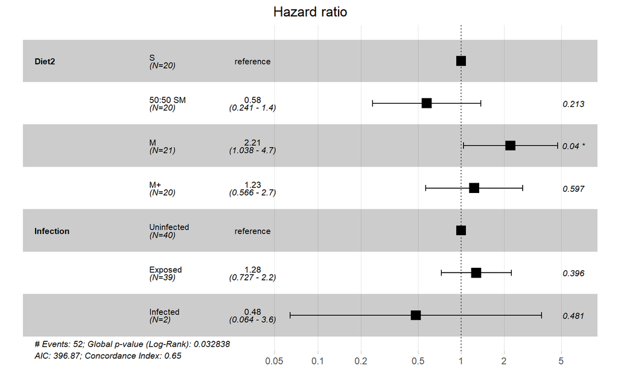

```r
ggforest(cox.diet_infstatus_std2, data = p_data_std)
```

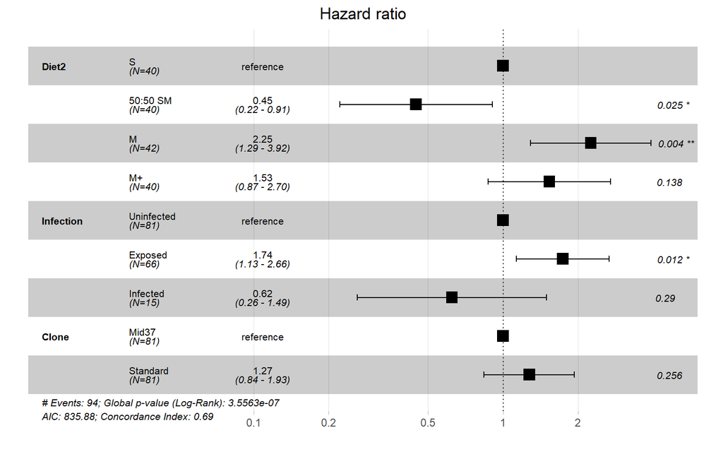

```r
# forest plot for presentation
past_cox <- ggforest(cox.diet_infstatus_clone, data = p_data, cpositions = c(0.02, 0.15, 0.35))
past_cox
```

```r
ggsave("figures/PastCoxHazard_DietxClonexInfection.tiff", plot = past_cox, dpi = 600, width = 6, height = 4, units = "in", compression="lzw")

# NOTE: the forest plot has a problem plotting the reference if it starts with the same letter as another factor in the same variable (e.g. S and SM), but the analysis runs correctly
```

**Mid37 survival in the Pasteuria experiment**

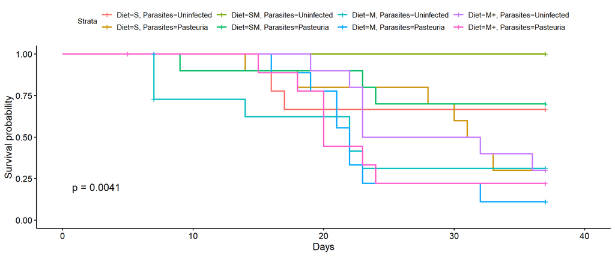

```r
p_data_mid$SurvObj <- with(p_data_mid, Surv(lifespan.days, Status))

# Kaplan-Meier estimator with "log-log" confidence interval
km.by.diet_parasite_mid <- survfit(SurvObj ~ Diet + Parasites, data = p_data_mid, conf.type = "log-log")
km.by.diet_infstatus_mid <- survfit(SurvObj ~ Diet + Infection, data = p_data_mid, conf.type = "log-log")

ggsurvplot(km.by.diet_parasite_mid, data = p_data_mid, pval = TRUE, xlab = "Days")
```

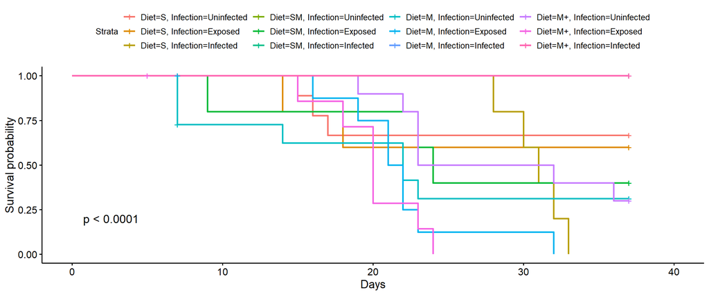

```r
ggsurvplot(km.by.diet_infstatus_mid, data = p_data_mid, pval = TRUE, xlab = "Days")
```

```r
# Cox proportional hazards model
cox.diet_parasite_mid <- coxph(SurvObj ~ Diet + Parasites, data = p_data_mid)
cox.diet_parasite_mid
```

```
## Call:
## coxph(formula = SurvObj ~ Diet + Parasites, data = p_data_mid)
##
##                       coef exp(coef) se(coef)      z      p
## DietSM             -1.3594    0.2568   0.6588 -2.064 0.0391
## DietM               0.8984    2.4556   0.4139  2.170 0.0300
## DietM+              0.6184    1.8560   0.4198  1.473 0.1407
## ParasitesPasteuria  0.5532    1.7389   0.3191  1.734 0.0830
##
## Likelihood ratio test=22.89  on 4 df, p=0.000133
## n= 81, number of events= 42
```

```r
cox.diet_infstatus_mid <- coxph(SurvObj ~ Diet + Infection, data = p_data_mid)
cox.diet_infstatus_mid
```

```
## Call:
## coxph(formula = SurvObj ~ Diet + Infection, data = p_data_mid)
##
##                      coef exp(coef) se(coef)      z       p
## DietSM            -1.3305    0.2643   0.6587 -2.020 0.04339
## DietM              0.7471    2.1109   0.4202  1.778 0.07540
## DietM+             0.5897    1.8035   0.4239  1.391 0.16421
## InfectionExposed   0.9269    2.5267   0.3435  2.699 0.00696
## InfectionInfected -0.2202    0.8023   0.5138 -0.429 0.66824
##
## Likelihood ratio test=28.76  on 5 df, p=2.585e-05
## n= 81, number of events= 42
```

```r
cox.diet_infstatus_mid2 <- coxph(SurvObj ~ Diet2 + Infection, data = p_data_mid)
cox.diet_infstatus_mid2
```

```
## Call:
## coxph(formula = SurvObj ~ Diet2 + Infection, data = p_data_mid)
##
##                      coef exp(coef) se(coef)      z       p
## Diet250:50 SM     -1.3305    0.2643   0.6587 -2.020 0.04339
## Diet2M             0.7471    2.1109   0.4202  1.778 0.07540
## Diet2M+            0.5897    1.8035   0.4239  1.391 0.16421
## InfectionExposed   0.9269    2.5267   0.3435  2.699 0.00696
## InfectionInfected -0.2202    0.8023   0.5138 -0.429 0.66824
##
## Likelihood ratio test=28.76  on 5 df, p=2.585e-05
## n= 81, number of events= 42
```

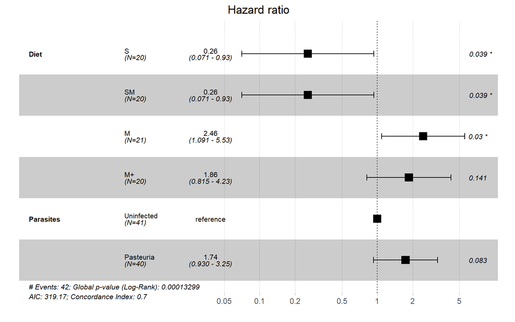

```r
# forest plot
ggforest(cox.diet_parasite_mid, data = p_data_mid)
```

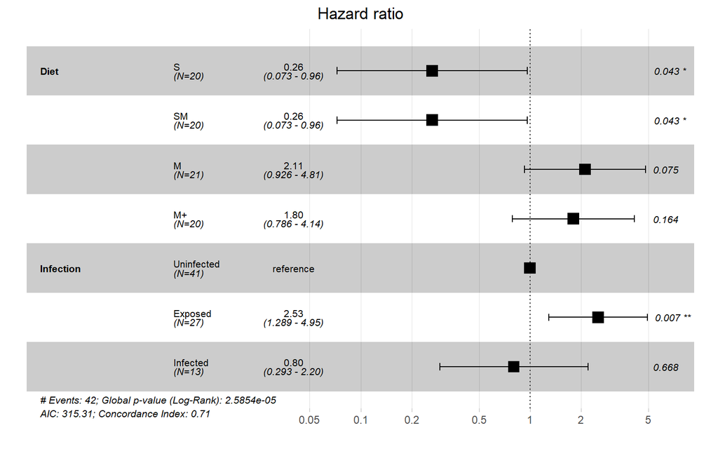

```r
ggforest(cox.diet_infstatus_mid, data = p_data_mid)
```

May need to make a treatment category for Diet x parasite or Diet x Infection Status to be able to see the interaction between the treatments more clearly. Including an interaction term in the Cox model doesn’t seem to be working when I try that…

Interestingly, pasteuria exposed animals suffered more mortality than then infected animals in Mid37s.

### Metsch survival analyses

```r
m_data$Diet2 = recode_factor(m_data$Diet, 'SM' = "50:50 SM", .default = levels(m_data$Diet))
m_data$Diet2 <- factor(m_data$Diet2, levels = c("S", "50:50 SM", "M", "M+"))

m_data$SurvObj <- with(m_data, Surv(lifespan.days, Status))

m_data_std <- m_data %>% filter(Clone == "Standard") %>% mutate(Treatment_Combo = paste(Diet, Infection, sep = "_"))
m_data_mid <- m_data %>% filter(Clone == "Mid37") %>% mutate(Treatment_Combo = paste(Diet, Infection, sep = "_"))
```

**Standard survival in the Metsch experiment**

```r
m_data_std$SurvObj <- with(m_data_std, Surv(lifespan.days, Status))

# Kaplan-Meier estimator with "log-log" confidence interval
km.by.diet_parasite_std <- survfit(SurvObj ~ Diet + Parasites, data = m_data_std, conf.type = "log-log")
km.by.diet_infstatus_std <- survfit(SurvObj ~ Diet + Infection, data = m_data_std, conf.type = "log-log")

#pairwise survdiff
res <- pairwise_survdiff(Surv(lifespan.days, Status) ~ Diet + Infection,
     data = m_data_std)
res
```

```
##
##  Pairwise comparisons using Log-Rank test
##
## data:  m_data_std and Diet + Infection
##
##                               Diet=S, Infection=Uninfected
## Diet=S, Infection=Exposed     0.00034
## Diet=S, Infection=Infected    0.00631
## Diet=SM, Infection=Uninfected 0.15522
## Diet=SM, Infection=Exposed    0.11943
## Diet=SM, Infection=Infected   0.15522
## Diet=M, Infection=Uninfected  0.15522
## Diet=M, Infection=Exposed     0.07618
## Diet=M+, Infection=Uninfected 0.52424
## Diet=M+, Infection=Exposed    0.37737
## Diet=M+, Infection=Infected   0.31017
##                               Diet=S, Infection=Exposed
## Diet=S, Infection=Exposed     -
## Diet=S, Infection=Infected    6.5e-05
## Diet=SM, Infection=Uninfected 7.1e-05
## Diet=SM, Infection=Exposed    0.06440
## Diet=SM, Infection=Infected   0.01940
## Diet=M, Infection=Uninfected  7.1e-05
## Diet=M, Infection=Exposed     0.15522
## Diet=M+, Infection=Uninfected 0.00012
## Diet=M+, Infection=Exposed    8.4e-05
## Diet=M+, Infection=Infected   0.09371
##                               Diet=S, Infection=Infected
## Diet=S, Infection=Exposed     -
## Diet=S, Infection=Infected    -
## Diet=SM, Infection=Uninfected 2.1e-05
## Diet=SM, Infection=Exposed    0.31017
## Diet=SM, Infection=Infected   0.15522
## Diet=M, Infection=Uninfected  2.1e-05
## Diet=M, Infection=Exposed     0.70667
## Diet=M+, Infection=Uninfected 0.00019
## Diet=M+, Infection=Exposed    0.03681
## Diet=M+, Infection=Infected   0.11943
##                               Diet=SM, Infection=Uninfected
## Diet=S, Infection=Exposed     -
```

[output cut: 62 more lines]

```
## Diet=M+, Infection=Exposed    0.11166
## Diet=M+, Infection=Infected   0.07618
##                               Diet=M+, Infection=Exposed
## Diet=S, Infection=Exposed     -
## Diet=S, Infection=Infected    -
## Diet=SM, Infection=Uninfected -
## Diet=SM, Infection=Exposed    -
## Diet=SM, Infection=Infected   -
## Diet=M, Infection=Uninfected  -
## Diet=M, Infection=Exposed     -
## Diet=M+, Infection=Uninfected -
## Diet=M+, Infection=Exposed    -
## Diet=M+, Infection=Infected   0.70667
##
## P value adjustment method: BH
```

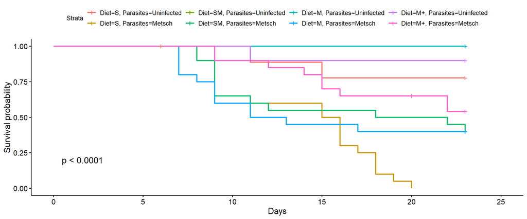

```r
ggsurvplot(km.by.diet_parasite_std, data = m_data_std, pval = TRUE, xlab = "Days")
```

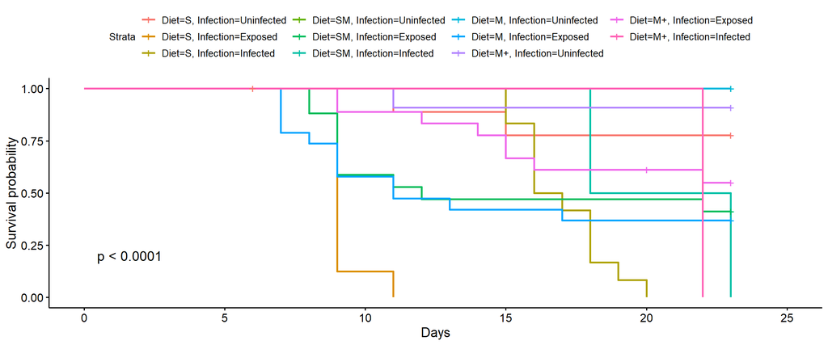

```r
ggsurvplot(km.by.diet_infstatus_std, data = m_data_std, pval = TRUE, xlab = "Days")
```

```r
# Cox proportional hazards model
cox.m_diet_parasite_std <- coxph(SurvObj ~ Diet + Parasites, data = m_data_std)
cox.m_diet_parasite_std
```

```
## Call:
## coxph(formula = SurvObj ~ Diet + Parasites, data = m_data_std)
##
##                    coef exp(coef) se(coef)      z        p
## DietSM          -0.8694    0.4192   0.3671 -2.369  0.01785
## DietM           -0.7081    0.4926   0.3664 -1.933  0.05329
## DietM+          -1.2577    0.2843   0.3888 -3.235  0.00122
## ParasitesMetsch  2.6557   14.2347   0.5964  4.453 8.46e-06
##
## Likelihood ratio test=52.83  on 4 df, p=9.242e-11
## n= 120, number of events= 56
```

```r
cox.m_diet_infstatus_std <- coxph(SurvObj ~ Diet + Infection, data = m_data_std)
summary(cox.m_diet_infstatus_std)
```

```
## Call:
## coxph(formula = SurvObj ~ Diet + Infection, data = m_data_std)
##
##   n= 120, number of events= 56
##
##                      coef exp(coef) se(coef)      z Pr(>|z|)
## DietSM            -1.4043    0.2455   0.4584 -3.063 0.002189 **
## DietM             -1.3182    0.2676   0.4742 -2.780 0.005443 **
## DietM+            -1.8764    0.1531   0.4906 -3.824 0.000131 ***
## InfectionExposed   3.1332   22.9475   0.6243  5.019  5.2e-07 ***
## InfectionInfected  2.1860    8.8996   0.6568  3.328 0.000874 ***
## ---
## Signif. codes:  0 '***' 0.001 '**' 0.01 '*' 0.05 '.' 0.1 ' ' 1
##
##                   exp(coef) exp(-coef) lower .95 upper .95
## DietSM               0.2455    4.07257   0.09998    0.6030
## DietM                0.2676    3.73676   0.10564    0.6779
## DietM+               0.1531    6.52979   0.05854    0.4006
## InfectionExposed    22.9475    0.04358   6.75043   78.0082
## InfectionInfected    8.8996    0.11236   2.45624   32.2459
##
## Concordance= 0.776  (se = 0.027 )
## Likelihood ratio test= 62.43  on 5 df,   p=4e-12
## Wald test            = 34.67  on 5 df,   p=2e-06
## Score (logrank) test = 50.15  on 5 df,   p=1e-09
```

```r
cox.m_diet_infstatus_std2 <- coxph(SurvObj ~ Diet2 + Infection, data = m_data_std)
summary(cox.m_diet_infstatus_std2)
```

```
## Call:
## coxph(formula = SurvObj ~ Diet2 + Infection, data = m_data_std)
##
##   n= 120, number of events= 56
##
##                      coef exp(coef) se(coef)      z Pr(>|z|)
## Diet250:50 SM     -1.4043    0.2455   0.4584 -3.063 0.002189 **
## Diet2M            -1.3182    0.2676   0.4742 -2.780 0.005443 **
## Diet2M+           -1.8764    0.1531   0.4906 -3.824 0.000131 ***
## InfectionExposed   3.1332   22.9475   0.6243  5.019  5.2e-07 ***
## InfectionInfected  2.1860    8.8996   0.6568  3.328 0.000874 ***
## ---
## Signif. codes:  0 '***' 0.001 '**' 0.01 '*' 0.05 '.' 0.1 ' ' 1
##
##                   exp(coef) exp(-coef) lower .95 upper .95
## Diet250:50 SM        0.2455    4.07257   0.09998    0.6030
## Diet2M               0.2676    3.73676   0.10564    0.6779
## Diet2M+              0.1531    6.52979   0.05854    0.4006
## InfectionExposed    22.9475    0.04358   6.75043   78.0082
## InfectionInfected    8.8996    0.11236   2.45624   32.2459
##
## Concordance= 0.776  (se = 0.027 )
## Likelihood ratio test= 62.43  on 5 df,   p=4e-12
## Wald test            = 34.67  on 5 df,   p=2e-06
## Score (logrank) test = 50.15  on 5 df,   p=1e-09
```

```r
m_data$SurvObj <- with(m_data, Surv(lifespan.days, Status))
cox.m_diet_infstatus_clone <- coxph(SurvObj ~ Diet2 + Infection +Clone, data = m_data)
summary(cox.m_diet_infstatus_clone)
```

```
## Call:
## coxph(formula = SurvObj ~ Diet2 + Infection + Clone, data = m_data)
##
##   n= 242, number of events= 99
##
##                      coef exp(coef) se(coef)      z Pr(>|z|)
## Diet250:50 SM     -1.0662    0.3443   0.3093 -3.447 0.000566 ***
## Diet2M            -1.2299    0.2923   0.3283 -3.746 0.000180 ***
## Diet2M+           -1.9314    0.1449   0.3632 -5.317 1.05e-07 ***
## InfectionExposed   2.9922   19.9286   0.4746  6.305 2.88e-10 ***
## InfectionInfected  2.2693    9.6723   0.5063  4.482 7.40e-06 ***
## CloneStandard      0.5502    1.7337   0.2080  2.645 0.008172 **
## ---
## Signif. codes:  0 '***' 0.001 '**' 0.01 '*' 0.05 '.' 0.1 ' ' 1
##
##                   exp(coef) exp(-coef) lower .95 upper .95
## Diet250:50 SM        0.3443    2.90423   0.18781    0.6313
## Diet2M               0.2923    3.42082   0.15360    0.5564
## Diet2M+              0.1449    6.89946   0.07112    0.2954
## InfectionExposed    19.9286    0.05018   7.86194   50.5156
## InfectionInfected    9.6723    0.10339   3.58540   26.0927
## CloneStandard        1.7337    0.57681   1.15314    2.6064
##
## Concordance= 0.784  (se = 0.021 )
## Likelihood ratio test= 109.5  on 6 df,   p=<2e-16
## Wald test            = 66.01  on 6 df,   p=3e-12
## Score (logrank) test = 89.3  on 6 df,   p=<2e-16
```

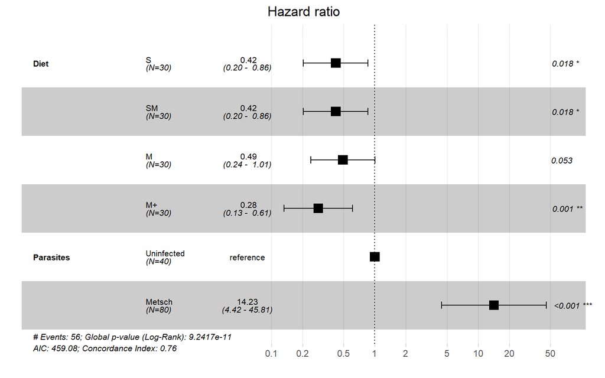

```r
# forest plot
ggforest(cox.m_diet_parasite_std, data = m_data_std)
```

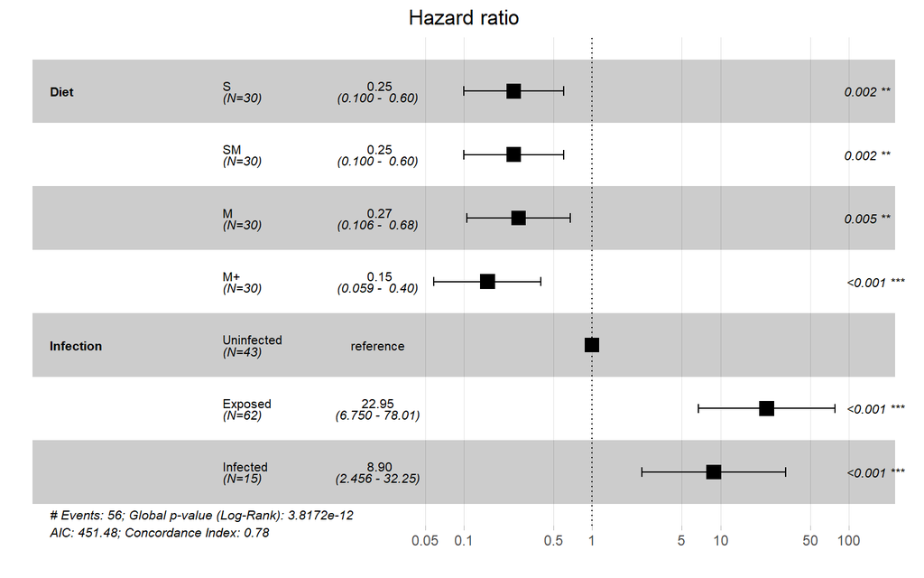

```r
ggforest(cox.m_diet_infstatus_std, data = m_data_std)
```

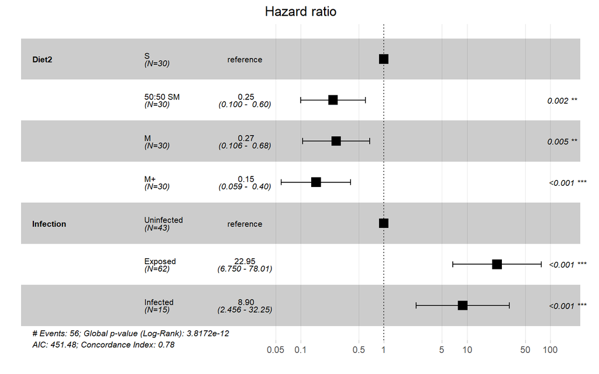

```r
ggforest(cox.m_diet_infstatus_std2, data = m_data_std)
```

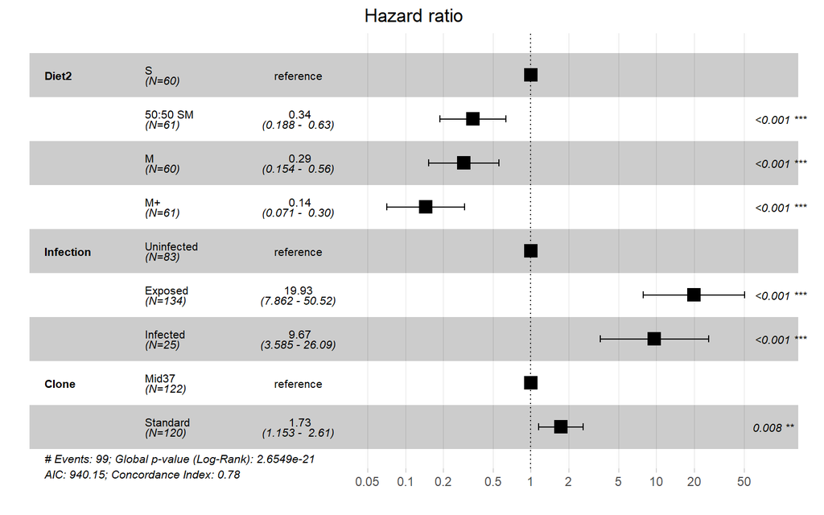

```r
# forest plot for presentation
metsch_cox <- ggforest(cox.m_diet_infstatus_clone, data = m_data, cpositions = c(0.02, 0.15, 0.35))
metsch_cox
```

```r
ggsave("figures/MetschCoxHazard_DietxClonexInfection.tiff", plot = metsch_cox, dpi = 600, width = 5.5, height = 4, units = "in", compression="lzw")
```

Animals that were exposed to or infected with metsch experienced much greater risk of death!

**Mid37 survival in the Metsch experiment**

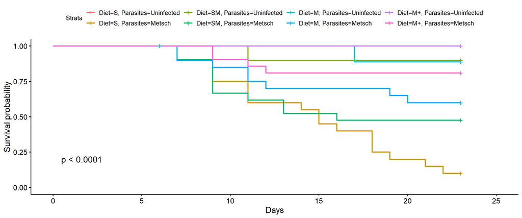

```r
m_data_mid$SurvObj <- with(m_data_mid, Surv(lifespan.days, Status))

# Kaplan-Meier estimator with "log-log" confidence interval
km.by.diet_parasite_mid <- survfit(SurvObj ~ Diet + Parasites, data = m_data_mid, conf.type = "log-log")
km.by.diet_infstatus_mid <- survfit(SurvObj ~ Diet + Infection, data = m_data_mid, conf.type = "log-log")

ggsurvplot(km.by.diet_parasite_mid, data = m_data_mid, pval = TRUE, xlab = "Days")
```

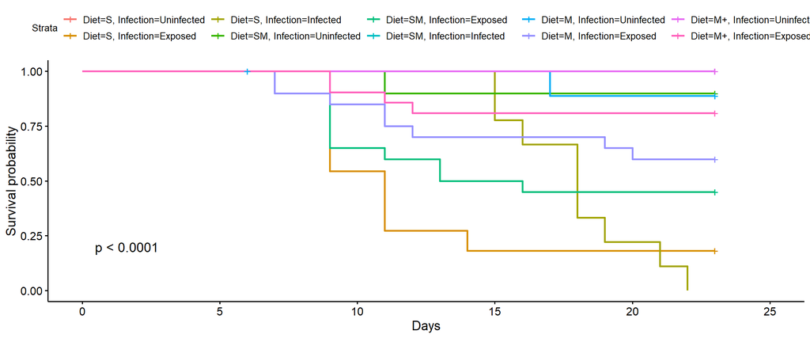

```r
ggsurvplot(km.by.diet_infstatus_mid, data = m_data_mid, pval = TRUE, xlab = "Days")
```

```r
# Cox proportional hazards model
cox.m_diet_parasite_mid <- coxph(SurvObj ~ Diet + Parasites, data = m_data_mid)
cox.m_diet_parasite_mid
```

```
## Call:
## coxph(formula = SurvObj ~ Diet + Parasites, data = m_data_mid)
##
##                    coef exp(coef) se(coef)      z        p
## DietSM          -0.5072    0.6022   0.3747 -1.353 0.175908
## DietM           -0.9383    0.3913   0.4117 -2.279 0.022654
## DietM+          -1.9223    0.1463   0.5562 -3.456 0.000548
## ParasitesMetsch  2.6966   14.8287   0.7261  3.714 0.000204
##
## Likelihood ratio test=45.15  on 4 df, p=3.704e-09
## n= 122, number of events= 43
```

```r
cox.m_diet_infstatus_mid <- coxph(SurvObj ~ Diet + Infection, data = m_data_mid)
cox.m_diet_infstatus_mid
```

```
## Call:
## coxph(formula = SurvObj ~ Diet + Infection, data = m_data_mid)
##
##                      coef exp(coef) se(coef)      z        p
## DietSM            -0.7134    0.4900   0.4232 -1.686 0.091846
## DietM             -1.1739    0.3092   0.4680 -2.508 0.012131
## DietM+            -2.1584    0.1155   0.5993 -3.602 0.000316
## InfectionExposed   2.8316   16.9721   0.7390  3.831 0.000127
## InfectionInfected  2.3895   10.9080   0.7969  2.999 0.002713
##
## Likelihood ratio test=46.09  on 5 df, p=8.693e-09
## n= 122, number of events= 43
```

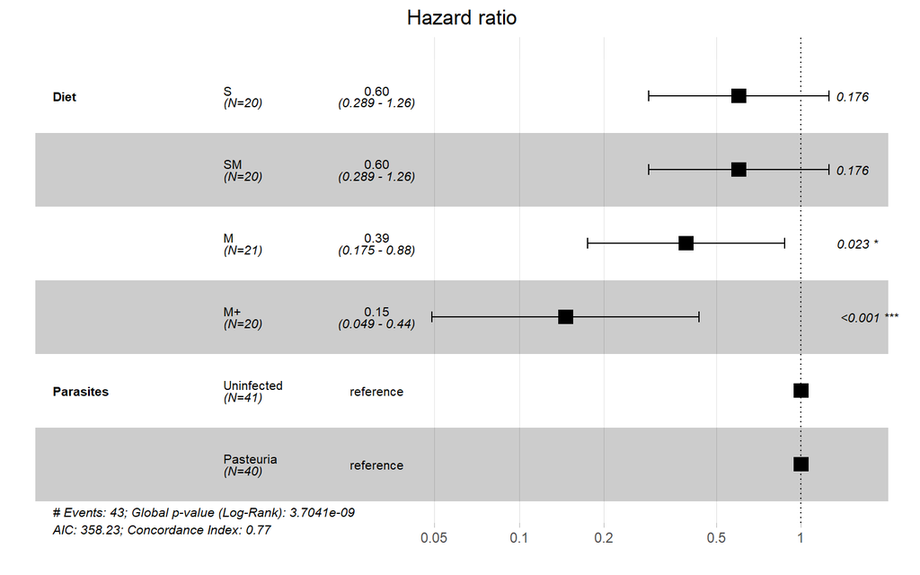

```r
# forest plot
ggforest(cox.m_diet_parasite_mid, data = p_data_mid)
```

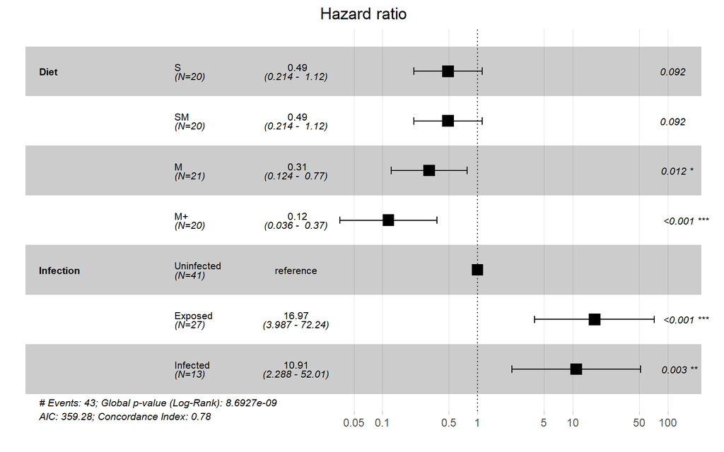

```r
ggforest(cox.m_diet_infstatus_mid, data = p_data_mid)
```

Animals that were exposed to or infected with metsch experienced much greater risk of death!

Not sure why both the uninfected and metsch treatments are considered reference in the first figure…

### Lifespan figures

Pasteuria lifespan

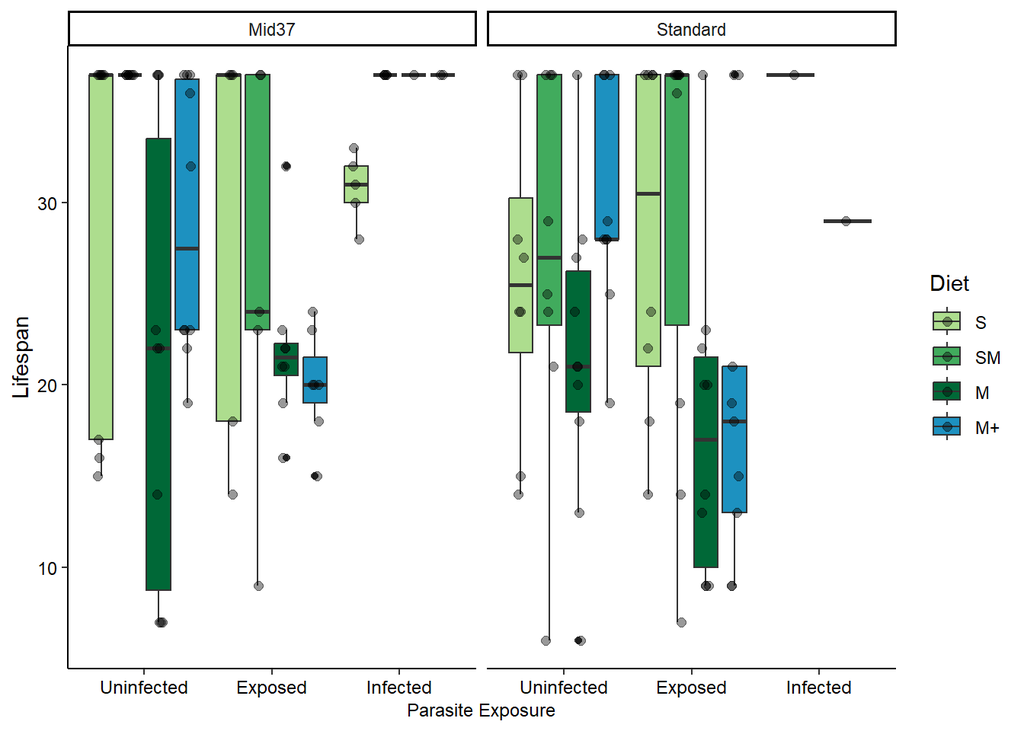

```r
# figure for presentation
p_data_lifespan <- p_data %>% filter(Include_Lifespan == "Y")

p_lifespan <- ggplot(p_data_lifespan, aes(x = Infection, y = Lifespan)) +
  geom_boxplot(aes(fill=Diet),position=position_dodge(width =0.9)) +
  geom_point(aes(color=Diet), size=2, position=position_jitterdodge(dodge.width=0.9, jitter.width = 0.2), alpha = 0.4) +
  facet_wrap(~Clone) +
  scale_x_discrete(limits = c("Uninfected", "Exposed", "Infected")) +
  scale_fill_discrete(limits = c("S", "SM", "M", "M+")) +
  scale_fill_manual(values = diet_colors) +
  scale_color_manual(values = c(rep("black", 4))) +
  #ggtitle("Growth Rate from Week 1 to 2 by infection status x diet x host clone for Past Expt") +
  labs(x = "Parasite Exposure", y = "Lifespan") +
  theme_classic() +
  theme(axis.text = element_text(size=9, color = "black"), axis.title.y = element_text(size=11, color="black"),
        axis.title.x = element_text(size=9, color="black"))
p_lifespan
```

```r
ggsave("figures/PastLifespan_DietxClonexInfection.tiff", plot = p_lifespan, dpi = 600, width = 6.5, height = 4, units = "in", compression="lzw")
```

Metsch lifespan

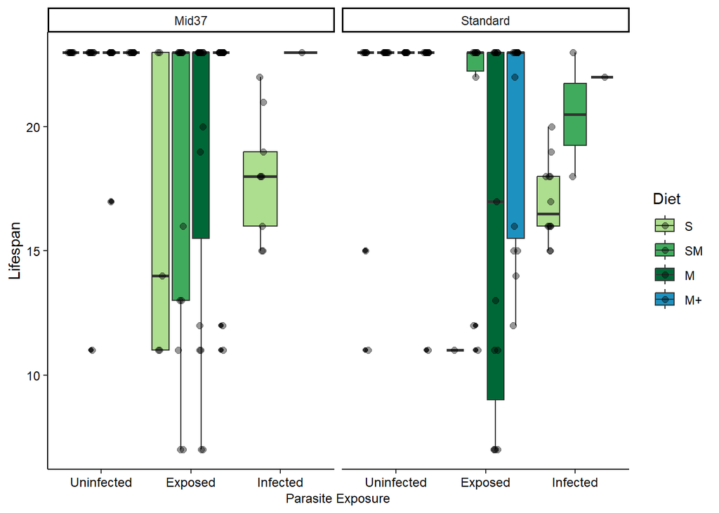

```r
# figure for presentation
m_data_lifespan <- m_data %>% filter(Include_Lifespan == "Y")


m_lifespan <- ggplot(m_data_lifespan, aes(x = Infection, y = Lifespan)) +
  geom_boxplot(aes(fill=Diet),position=position_dodge(width =0.9)) +
  geom_point(aes(color=Diet), size=2, position=position_jitterdodge(dodge.width=0.9, jitter.width = 0.2), alpha = 0.4) +
  facet_wrap(~Clone) +
  scale_x_discrete(limits = c("Uninfected", "Exposed", "Infected")) +
  scale_fill_discrete(limits = c("S", "SM", "M", "M+")) +
  scale_fill_manual(values = diet_colors) +
  scale_color_manual(values = c(rep("black", 4))) +
  #ggtitle("Growth Rate from Week 1 to 2 by infection status x diet x host clone for Past Expt") +
  labs(x = "Parasite Exposure", y = "Lifespan") +
  theme_classic() +
  theme(axis.text = element_text(size=9, color = "black"), axis.title.y = element_text(size=11, color="black"),
        axis.title.x = element_text(size=9, color="black"))
m_lifespan
```

```r
ggsave("figures/MetschLifespan_DietxClonexInfection.tiff", plot = m_lifespan, dpi = 600, width = 6.5, height = 4, units = "in", compression="lzw")
```